# Study title

# 6 Models

Based on the data we have, we can ask a few questions: 1. Do the number of detections differ with location, night, or the weather? 2. Do the number of species observed with location, night, or the weather?

For both these questions we are dealing with continuous responses (`detections` and `species_n`), and both categorical predictors (`location`) and continuous predictors (`study_night`, `minimum_temperature`, `maximum_temperature`, `rainfall`). To deal with these mixed-type predictors, we’ll fit generalised linear models (GLMs).

The benefit of GLMs is they can deal with such categorical predictors, are relatively easy to interpret, and are robust against overfitting. However, they are sensitive to outliers, and can’t deal with presence-only data.

```r
# Fit a GLM
mod <- glm(detections ~ location + study_night +
             minimum_temperature + maximum_temperature +
             rainfall, data=data)

# Display summary statistics
summary(mod)
```

```
##
## Call:
## glm(formula = detections ~ location + study_night + minimum_temperature +
##     maximum_temperature + rainfall, data = data)
##
## Coefficients: (2 not defined because of singularities)
##                       Estimate Std. Error t value Pr(>|t|)
## (Intercept)         -3.621e+04  1.909e+04  -1.897   0.0630 .
## locationMFWS         1.387e+01  1.187e+00  11.681   <2e-16 ***
## study_night          2.112e-05  1.113e-05   1.898   0.0629 .
## minimum_temperature -2.625e-01  3.148e-01  -0.834   0.4079
## maximum_temperature         NA         NA      NA       NA
## rainfall                    NA         NA      NA       NA
## ---
## Signif. codes:  0 '***' 0.001 '**' 0.01 '*' 0.05 '.' 0.1 ' ' 1
##
## (Dispersion parameter for gaussian family taken to be 21.13988)
##
##     Null deviance: 4150.4  on 59  degrees of freedom
## Residual deviance: 1183.8  on 56  degrees of freedom
## AIC: 359.2
##
## Number of Fisher Scoring iterations: 2
```

Since the `Pr(>|t|)` (or *p*) value for `location` is < 0.05, we found it significantly affected species `detections`! Let’s fit a GLM for our second question too.

```r
# Fit a GLM
mod <- glm(species_n ~ location + study_night +
             minimum_temperature + maximum_temperature +
             rainfall, data=data)

# Display summary statistics
summary(mod)
```

```
##
## Call:
## glm(formula = species_n ~ location + study_night + minimum_temperature +
##     maximum_temperature + rainfall, data = data)
##
## Coefficients: (2 not defined because of singularities)
##                       Estimate Std. Error t value Pr(>|t|)
## (Intercept)         -5.452e+03  4.148e+03  -1.314    0.194
## locationMFWS         3.400e+00  2.580e-01  13.180   <2e-16 ***
## study_night          3.183e-06  2.419e-06   1.316    0.194
## minimum_temperature -8.750e-02  6.840e-02  -1.279    0.206
## maximum_temperature         NA         NA      NA       NA
## rainfall                    NA         NA      NA       NA
## ---
## Signif. codes:  0 '***' 0.001 '**' 0.01 '*' 0.05 '.' 0.1 ' ' 1
##
## (Dispersion parameter for gaussian family taken to be 0.9982143)
##
##     Null deviance: 231.33  on 59  degrees of freedom
## Residual deviance:  55.90  on 56  degrees of freedom
## AIC: 176.03
##
## Number of Fisher Scoring iterations: 2
```

Once again, `location` significantly affected the number of species observed!

# 7 Plots

Let’s plot our significant results. This is relatively simple for question 1 using a violin plot (with some extras).

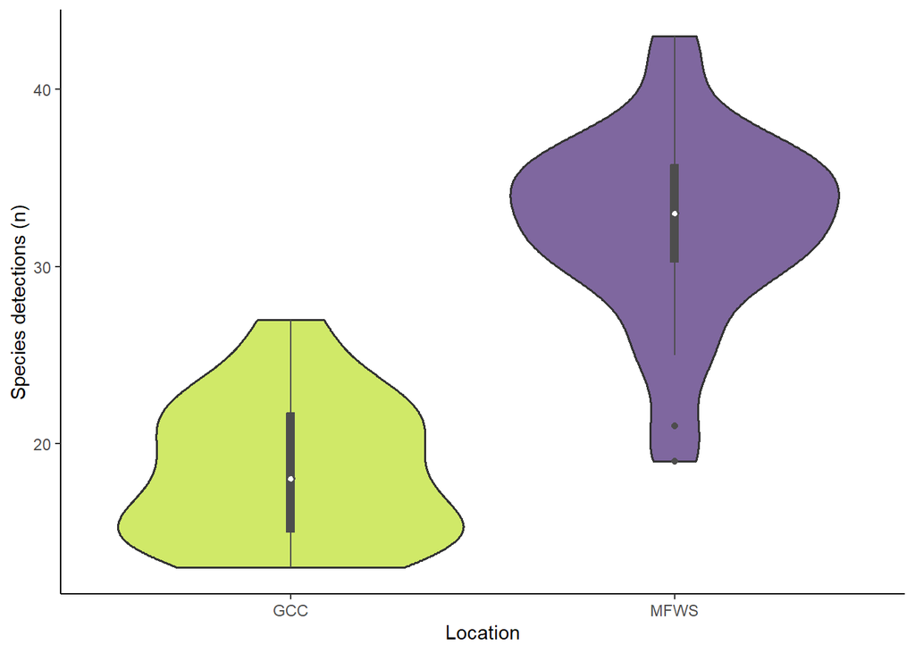

```r
# Violin plot detections by location
det_loc_plot <- ggplot(data=data, aes(x=location, y=detections)) +
  # Plot frequency of values
  geom_violin(aes(fill=location), alpha=0.7, lwd=0.6) +
  # Plot boxplot (1st–3rd quartile line and median dot)
  geom_boxplot(col="grey30", fill="grey30",
               width=0.02, lwd=0.5) +
  stat_summary(fun="median", geom="point",
               col="grey30", fill="white",
               shape=21, size=1.5, stroke=1) +
  theme(legend.position="none",
        axis.line=element_line(colour="black"),
        panel.background=element_rect(fill="white")) +
  scale_colour_manual(values=viridis(2, begin=0.9, end=0.1)) +
  scale_fill_manual(values=viridis(2, begin=0.9, end=0.1)) +
  xlab("Location") + ylab("Species detections (n)")

# Display the plot
print(det_loc_plot)
```

For question 2, we want to see how many of each species were observed at each location. Currently the data is in what R recognises as “wide format” (one column for each species). To create the plot we want, we need to change our species data so it is in “long format” (a column stating the species, and a second column with the number of detections for that species). Learn more here.

First we’ll tidy up the column names so they will plot better later. While it’s a bit inefficient to manually reverse the `clean_names()` function we used earlier, this exercise does show you how to rename columns which is always useful.

```r
# Rename the columns
data_wide <- data %>%
  rename("Eastern grey kangaroo" = eastern_grey_kangaroo,
         "Red-necked wallaby" = red_necked_wallaby,
         "Swamp wallaby" = swamp_wallaby,
         "Echidna" = echidna,
         "Wombat" = wombat,
         "Red fox" = red_fox,
         "Raven" = raven,
         "Eastern bettong" = eastern_bettong,
         "Pookila" = pookila,
         "Bush stone-curlew" = bush_stone_curlew,
         "Eastern quoll" = eastern_quoll,
         "Bandicoot" = bandicoot,
         "Other bird" = other_bird,
         "Other mammal" = other_mammal,
         "Other reptile" = other_reptile)

# Convert wide species data into long data
data_long <- pivot_longer(data=data_wide,
                          # Select column numbers pertaining to species
                          cols = 7:21,
                          # Label the two resulting columns
                          names_to = "species", values_to = "detections_n") %>%
  # Reorder the df by species
  arrange(species)
```

Now we can create a barplot where each bar is a species.

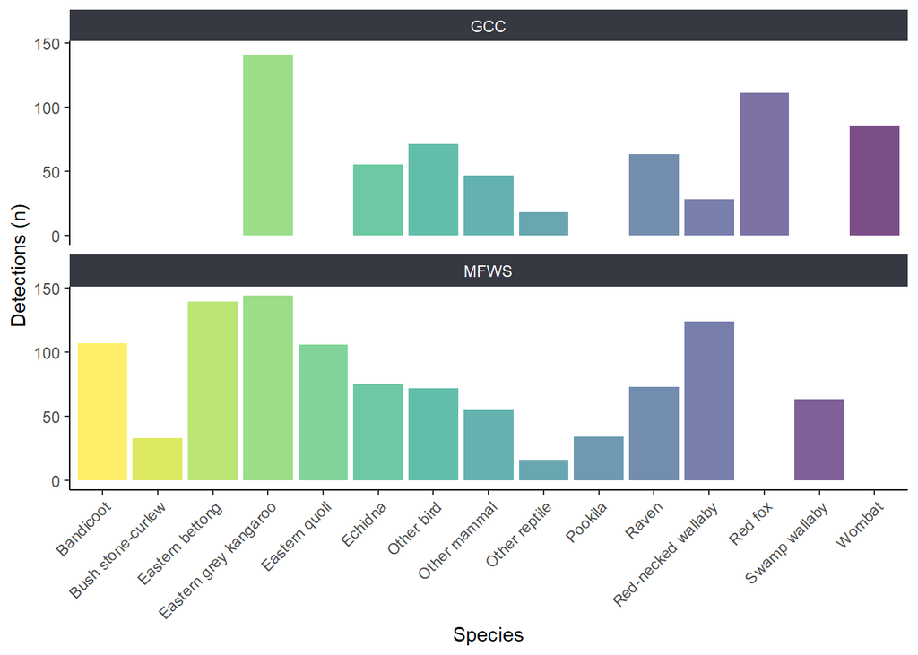

```r
# Barplot species by location
spe_loc_plot <- ggplot(data=data_long, aes(x=species, y=detections_n)) +
  # Plot frequency of values
  geom_col(aes(fill=species), alpha=0.7, lwd=0.6) +
  # Plot boxplot (1st–3rd quartile line and median dot)
  theme(legend.position="none",
        axis.line=element_line(colour="black"),
        # Rotate x-axis labels by 45 degrees
        axis.text.x = element_text(angle = 45, hjust = 1),
        panel.background=element_rect(fill="white"),
        strip.background = element_rect(fill="#363842"),
        strip.text = element_text(colour="white")) +
  # Plot each category separately
  facet_wrap(~location, ncol=1) +
  scale_colour_manual(values=viridis(15, begin=1, end=0)) +
  scale_fill_manual(values=viridis(15, begin=1, end=0)) +
  xlab("Species") +
  ylab("Detections (n)")

# Display the plot
print(spe_loc_plot)
```

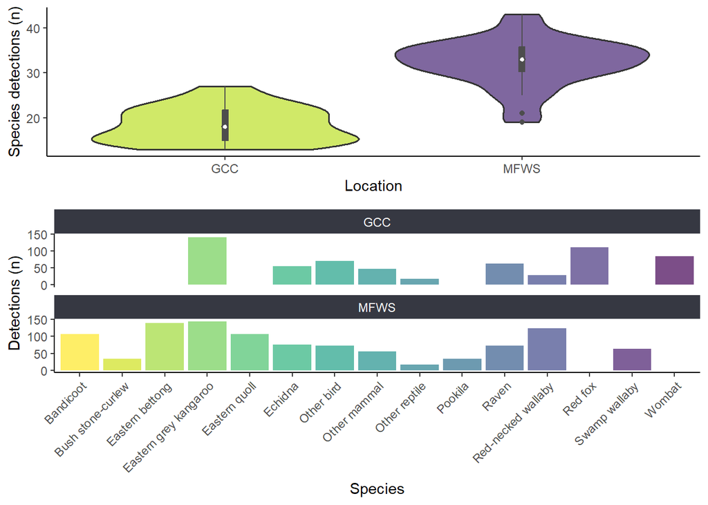

```r
# Combine plots
loc_plots <- ggarrange(det_loc_plot, spe_loc_plot,
                       ncol=1, nrow=2,
                       # Give second plot more height
                       heights=c(2, 3))

# Display the combined plot
print(loc_plots)
```

**A note on knitting your markdown**

Now that we’ve finished our analyses, we can *knit* the R markdown to produce a polished, presentable web document (html) to share with others! Go ahead and click `🧶 Knit` in the menu above.

**Note** that if the knitting options chunk in lines 19–21 states `eval=TRUE`, everything in your code will be run and its output will be included in the html (which is good practice!). However, if some part of your code isn’t working the knit won’t finish - but it will tell you what line of code it stopped at so you can fix it and try knitting again.

*Don’t want any of your code to run while knitting?*

If you’d rather your code not run at all while knitting (perhaps you have lots of analyses that aren’t quite working yet), change the `eval=TRUE` to `eval=FALSE` and you’ll generate a html with just your writing and coding, but no output.

*Don’t want a certain chunk to run while knitting?*

If you’d rather a specific chunk of code not run while knitting (perhaps it’s not quite working yet), above that chunk, change `{r}` to `{r, eval=FALSE}`. **Note** that if any code below this is dependent on the output of this chunk, they will no longer run either.